# 10-Tarea: bootstrap paramétrico

1. Sean $X_1,...,X_n \sim N(\mu, 1)$. Sea $\theta = e^{\mu}$, crea una base de datos usando $\mu=5$ que consista de $n=100$ observaciones.
- Usa el método delta para estimar $\hat{se}$ y crea un intervalo del 95% de confianza. Usa boostrap paramétrico para crear un intervalo del 95%. Usa bootstrap no paramétrico para crear un intervalo del 95%. Compara tus respuestas.

```r
# fijamos la semilla
set.seed(98765431)

# definimos los parámetros de la base de datos
mu <- 5
n <- 100

# simulaciones
normales <- rnorm(n = n, mean = mu, sd = 1)

# theta
theta <- exp(mean(normales))
se_theta <- abs(theta) * sd(normales) / sqrt(n)

# función para bootstrap paramétrico
b_param <- function(n, mu){
  sim <- rnorm(n, mu, 1)
  exp(mean(sim))
}

# función para bootstrap no paramétrico
b_noparam <- function(datos, n){
  smp <- sample(datos, n, replace = TRUE)
  exp(mean(smp))
}

# definimos el número de simulaciones para los bootstrap
num_sim <- 1000

# simulaciones bootstrap paramétrico
sim_param <- rerun(num_sim, b_param(n, mu)) %>% flatten_dbl

# simulaciones bootstrap no paramétrico
sim_noparam <- rerun(num_sim, b_noparam(normales, n)) %>% flatten_dbl

# intervalo de confianza método delta
ic_delta_inf <- theta - 1.96 * se_theta
ic_delta_sup <- theta + 1.96 * se_theta

# intervalo de confianza bootstrap paramétrico
ic_param_inf <- theta - 1.96 * sd(sim_param)
ic_param_sup <- theta + 1.96 * sd(sim_param)

# intervalo de confianza bootstrap no paramétrico
ic_noparam_inf <- theta - 1.96 * sd(sim_noparam)
ic_noparam_sup <- theta + 1.96 * sd(sim_noparam)

# matriz con los valores de los intervalos
ic_matriz <- matrix(c(ic_delta_inf, ic_param_inf, ic_noparam_inf, ic_delta_sup, ic_param_sup, ic_noparam_sup), ncol = 2)
rownames(ic_matriz) <- c("Método delta", "Bootstrap paramétrico", "Bootstrap no paramétrico")
colnames(ic_matriz) <- c("Límite inferior", "Límite superior")

kable(ic_matriz)
```

|  | Lmite inferior | Lmite superior |
| --- | --- | --- |
| Mtodo delta | 121.7296 | 177.7802 |
| Bootstrap paramtrico | 120.9811 | 178.5287 |
| Bootstrap no paramtrico | 120.6688 | 178.8411 |

- Realiza un histograma de replicaciones bootstrap para cada método, estas son estimaciones de la distribución de $\hat{\theta}$. El método delta también nos da una aproximación a esta distribución: $Normal(\hat{\theta},\hat{se}^2)$. Comparalos con la verdadera distribución de $\hat{\theta}$ (que puedes obtener vía simulación). ¿Cuál es la aproximación más cercana a la verdadera distribución?

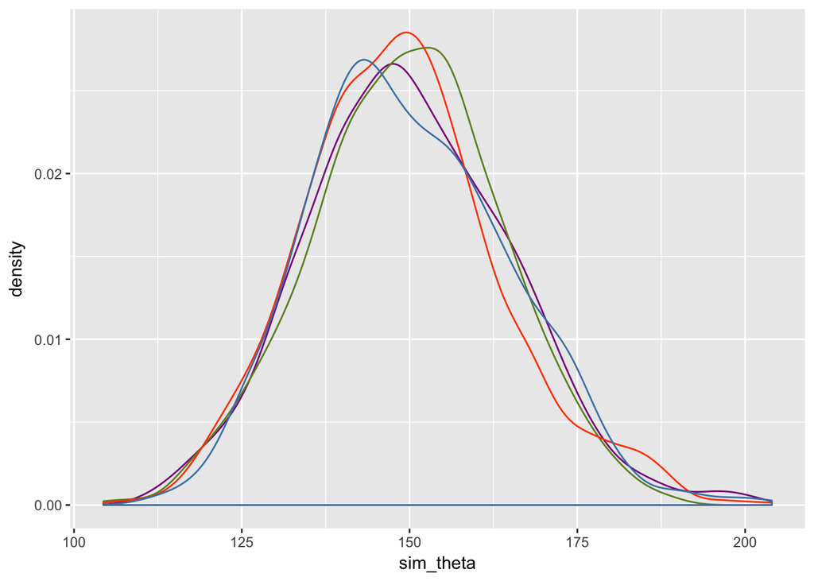

```r
# generamos las simulaciones del método delta
sim_delta <- rnorm(num_sim, theta, se_theta)

# simulamos la distribución verdadera de theta_hat
sim_theta <- rnorm(num_sim, theta, 13)

dist <- function(n, mu){
  datos <- rnorm(n = n, mean = mu, sd = 1)
  exp(mean(datos))
}

sim_theta <- rerun(num_sim, dist(n, mu)) %>% flatten_dbl

# creamos un dataframe para ggplot
sim <- data_frame(sim_theta, sim_delta, sim_param, sim_noparam)

# histograma de las distribuciones
sim %>%
  ggplot() +
  geom_density(aes(x = sim_theta), color = "darkmagenta") +
  geom_density(aes(x = sim_delta), color = "olivedrab") +
  geom_density(aes(x = sim_param), color = "orangered") +
  geom_density(aes(x = sim_noparam), color = "steelblue")
```

Pista: $se(\hat{\mu}) = 1/\sqrt{n}$

2. La base de datos vancouver.csv contiene promedios de precipitación de mediciones (en mm) provenientes de Vancouver entre 1960 y 1994.

```r
vancouver <- read_csv("./vancouver.csv")
kable(head(vancouver))
```

| id | date | prec |
| --- | --- | --- |
| 182 | jul01 | 1.6 |
| 183 | jul02 | 0.6 |
| 184 | jul03 | 3.1 |
| 185 | jul04 | 1.0 |
| 186 | jul05 | 3.9 |
| 187 | jul06 | 0.4 |

- Utiliza b-splines cúbicos para estudiar la relación entre el día y el promedio registrado. Deberás crear una variable numérica x que represente el día y utiliza como nudos los extremos y 3 puntos interiores igualmente espaciados, es decir, tendrás 4 regiones. Grafica la curva estimada.

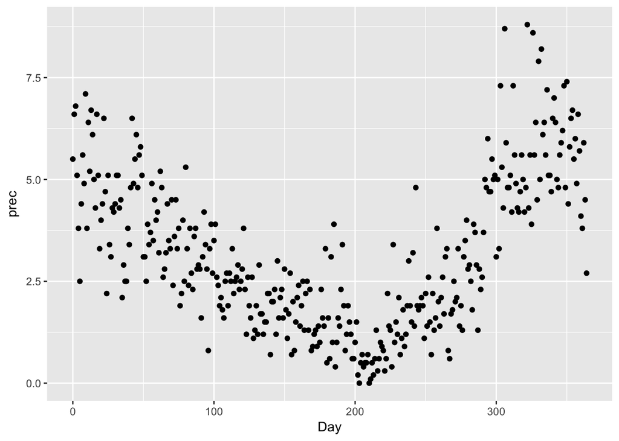

```r
# extraemos el dia de la fecha
vancouver_mod <- vancouver %>%
  mutate(Day = as.numeric(parse_date(paste(1970, substr(date, 1, 3), parse_number(date), sep = "-"), format = "%Y-%b-%d")))

# observamos los datos
vancouver_mod %>%
  ggplot(aes(Day, prec)) +
  geom_point()
```

```r
# definimos los nudos del spline
nudos <- quantile(vancouver_mod$Day)

# creamos la base para el spline
base <- create.bspline.basis(norder = 4, breaks = nudos)

# evaluamos la base
H <- eval.basis(vancouver_mod$Day, base)
kable(head(H))
```

| bspl4.1 | bspl4.2 | bspl4.3 | bspl4.4 | bspl4.5 | bspl4.6 | bspl4.7 |
| --- | --- | --- | --- | --- | --- | --- |
| 0 | 3e-07 | 0.1722208 | 0.6665466 | 0.1612323 | 0.00e+00 | 0 |
| 0 | 0e+00 | 0.1666667 | 0.6666667 | 0.1666667 | 0.00e+00 | 0 |
| 0 | 0e+00 | 0.1612323 | 0.6665466 | 0.1722208 | 3.00e-07 | 0 |
| 0 | 0e+00 | 0.1559174 | 0.6661889 | 0.1778910 | 2.70e-06 | 0 |
| 0 | 0e+00 | 0.1507206 | 0.6655978 | 0.1836727 | 9.00e-06 | 0 |
| 0 | 0e+00 | 0.1456406 | 0.6647770 | 0.1895612 | 2.12e-05 | 0 |

```r
# obtenemos los parámetros beta
beta_hat <- as.vector(solve(t(H) %*% H) %*% t(H) %*% vancouver_mod$prec)
beta_hat
```

```
## [1] 5.3249418 4.5726105 2.7577351 1.1963219 0.6707482 8.2273107 4.5611793
```

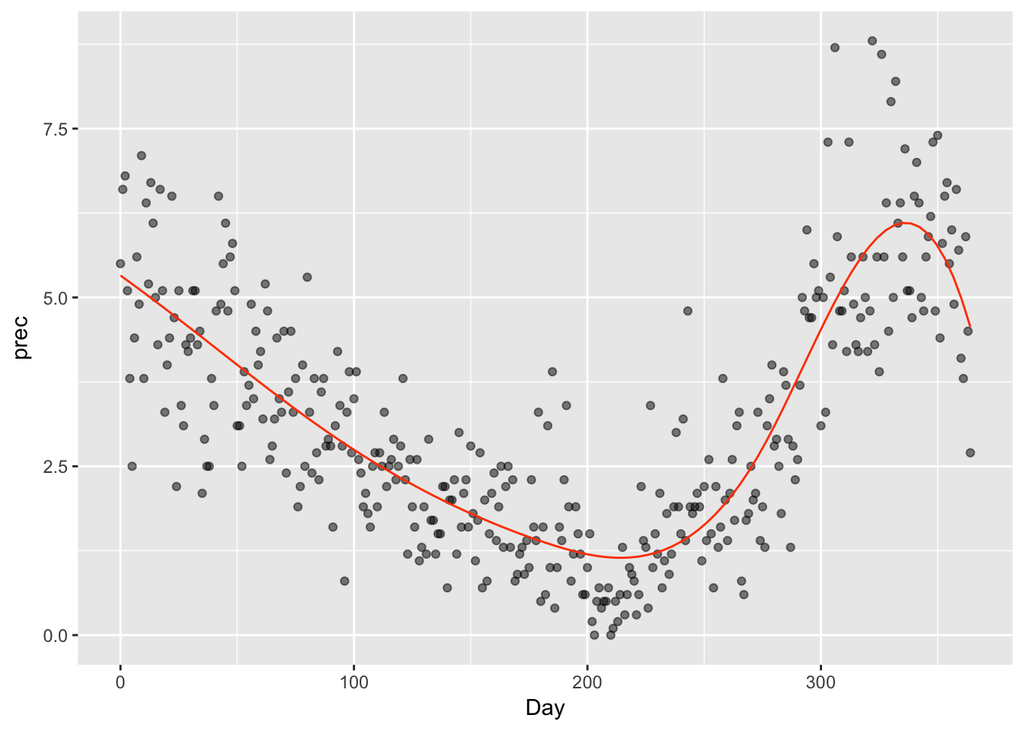

```r
# creamos la función auxiliar
f_mu <- function(x, betas){
    as.numeric(betas %*% t(eval.basis(x, base)))
}

# curva del splines ajustado
vancouver_mod %>%
  ggplot(aes(Day, prec)) +
    geom_point(alpha = 0.5) +
    stat_function(fun = f_mu, args = list(betas = beta_hat), color = "orangered")
```

- Crea bandas de errores estándar usando bootstrap paramético y suponiendo que los errores tienen una distribución normal.

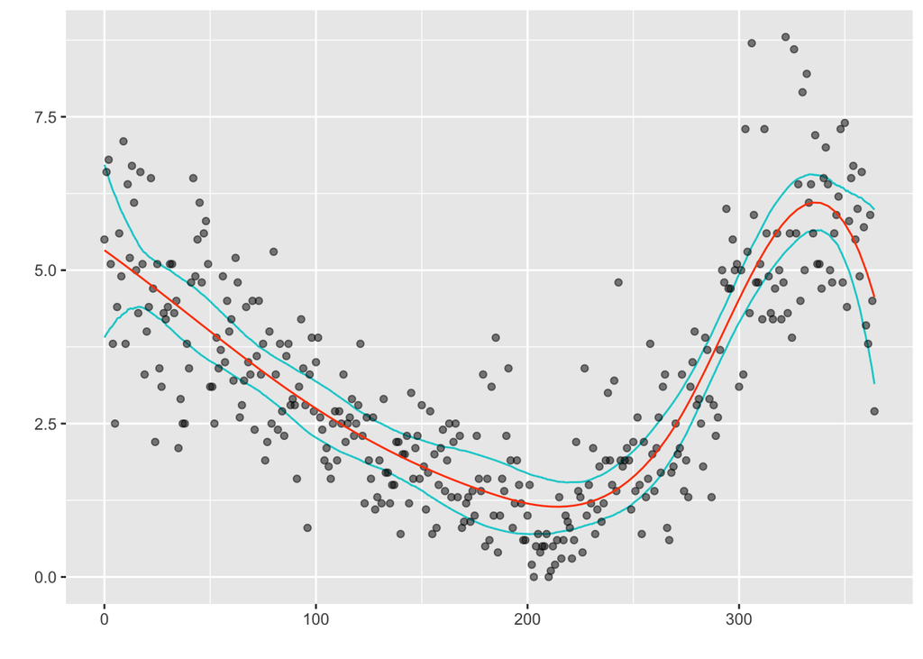

```r
mu_hat <- f_mu(vancouver_mod$Day, beta_hat)
sigma_hat <- sqrt(1 / n * sum((vancouver_mod$prec - mu_hat) ^ 2))

# creamos las muestras bootstrap (paramétrico)
splinesBootP <- function(){
    vancouver_boot <- data_frame(x = vancouver_mod$Day, y = mu_hat + rnorm(n, 0, sigma_hat))
    H <- eval.basis(vancouver_boot$x, base)
    as.vector(solve(t(H) %*% H) %*% t(H) %*% vancouver_boot$y)
}

betas_p <- rerun(num_sim, splinesBootP()) %>% reduce(rbind)

# construimos los intervalos
x_grid <- seq(nudos[1], nudos[5], 0.02)
H <- eval.basis(x_grid, base)
y <- betas_p %*% t(H)

betas_list <- split(betas_p, seq(nrow(betas_p)))

y <- purrr::map_df(betas_list, ~ data_frame(x = x_grid, mu = as.vector(. %*% t(H))))

# construimos los límites de los intervalos
limites <- y %>%
  group_by(x) %>%
  summarise(
    limite_inf = quantile(mu, probs = 0.025),
    limite_sup = quantile(mu, probs = 0.975)
    )

ggplot(limites) +
    geom_line(aes(x = x, y = limite_inf), color = "darkturquoise") +
    geom_line(aes(x = x, y = limite_sup), color = "darkturquoise") +
    geom_point(data = vancouver_mod, aes(x = Day, y = prec), color = "black", alpha = 0.5) +
    stat_function(fun = f_mu, args = list(betas = beta_hat), color = "orangered") +
    labs(x = "", y = "")
```